# Отчёт по лабораторной работе №11

## Запуск консольных приложений через SSH

Посмотрели с клиента почту на сервере (рис. 33).

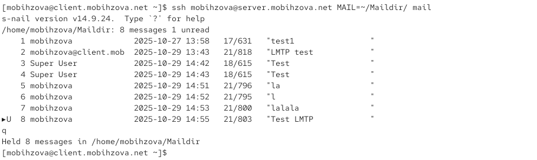

Рисунок 33: Удалённая работа с почтой

## Запуск графических приложений через SSH (X11Forwarding)

На сервере в конфигурационном файле /etc/ssh/sshd_config разрешили отображать на локальном клиентском компьютере графические интерфейсы X11: X11Forwarding yes (рис. 34).

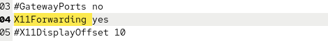

Рисунок 34: Включение X11Forwarding

## Запуск графических приложений через SSH (X11Forwarding)

Окно Firefox успешно отобразилось на клиентской машине (рис. 37).

[figure not shown]

Рисунок 37: Работа Firefox через X11Forwarding

## Внесение изменений в настройки внутреннего окружения виртуальной машины

На виртуальной машине server перешли в каталог для внесения изменений в настройки внутреннего окружения /vagrant/provision/server/, создали в нём каталог ssh, в который поместили в соответствующие подкаталоги конфигурационный файл sshd_config (рис. 38).

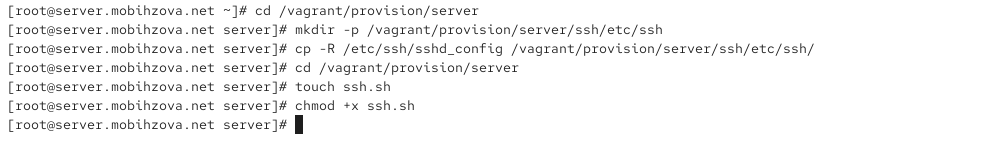

Рисунок 38: Создание структуры каталогов для конфигурации

## Внесение изменений в настройки внутреннего окружения виртуальной машины

В каталоге /vagrant/provision/server создали исполняемый файл ssh.sh (рис. 39).

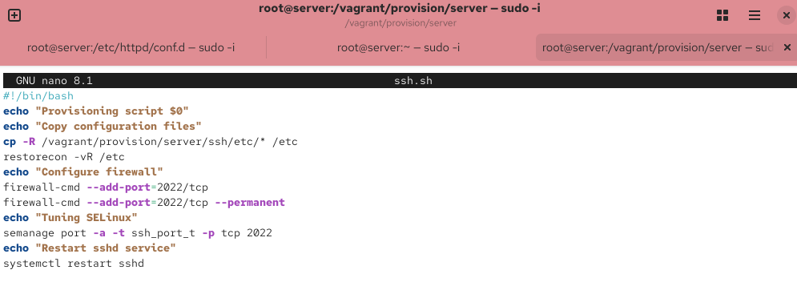

Рисунок 39: Создание скрипта настройки SSH

## Внесение изменений в настройки внутреннего окружения виртуальной машины

Для отработки созданного скрипта во время загрузки виртуальной машины server в конфигурационном файле Vagrantfile добавили в разделе конфигурации для сервера соответствующую запись (рис. 40).

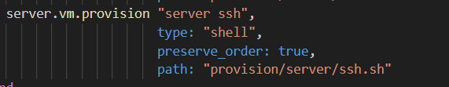

Рисунок 40: Добавление provisioning в Vagrantfile

# Выводы

## Выводы

В ходе выполнения лабораторной работы были приобретены практические навыки по настройке безопасного удалённого доступа к серверу с помощью SSH. Были выполнены все поставленные задачи по настройке безопасности SSH-сервера, включая запрет доступа для root, ограничение круга пользователей, настройку дополнительных портов, аутентизацию по ключам, организацию туннелей и запуск графических приложений.